# Workflow

### Chapter 4

R can be used as a calculator to compute basic sums.

```r
5+7
```

```
[1] 12
```

We can create new objects by assigning a value or a function to a name.

```r
x <- c(1,10)
y <- seq(1,10)
```

This object can then be called upon.

```r
x
```

```
[1]  1 10
```

```r
y
```

```
 [1]  1  2  3  4  5  6  7  8
 [9]  9 10
```

##### 4.4 Practice

1. Why does this code not work?

```r
my_variable <- 10
my_varıable
```

```
Error: object 'my_varıable' not found
```

The my_varıable object is not found because it is not identical to my_variable which has been assigned a value.

2. Tweaked versions of each of the R commands.

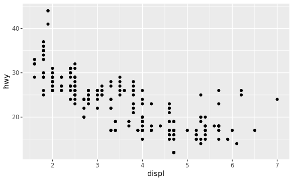

```r
library(tidyverse)
ggplot(data = mpg) +
  geom_point(mapping = aes(x = displ, y = hwy))
```

```r
filter(mpg, cyl == 8)
```

| manufacturer | model | displ | year | cyl | trans | drv | cty | hwy | fl | class |
| --- | --- | --- | --- | --- | --- | --- | --- | --- | --- | --- |
| audi | a6 quattro | 4.2 | 2008 | 8 | auto(s6) | 4 | 16 | 23 | p | midsize |
| chevrolet | c1500 suburban 2wd | 5.3 | 2008 | 8 | auto(l4) | r | 14 | 20 | r | suv |
| chevrolet | c1500 suburban 2wd | 5.3 | 2008 | 8 | auto(l4) | r | 11 | 15 | e | suv |
| chevrolet | c1500 suburban 2wd | 5.3 | 2008 | 8 | auto(l4) | r | 14 | 20 | r | suv |
| chevrolet | c1500 suburban 2wd | 5.7 | 1999 | 8 | auto(l4) | r | 13 | 17 | r | suv |
| chevrolet | c1500 suburban 2wd | 6.0 | 2008 | 8 | auto(l4) | r | 12 | 17 | r | suv |
| chevrolet | corvette | 5.7 | 1999 | 8 | manual(m6) | r | 16 | 26 | p | 2seater |
| chevrolet | corvette | 5.7 | 1999 | 8 | auto(l4) | r | 15 | 23 | p | 2seater |
| chevrolet | corvette | 6.2 | 2008 | 8 | manual(m6) | r | 16 | 26 | p | 2seater |
| chevrolet | corvette | 6.2 | 2008 | 8 | auto(s6) | r | 15 | 25 | p | 2seater |

[output cut: 60 more lines]

```r
filter(mpg, model == "corvette")
```

| manufacturer | model | displ | year | cyl | trans | drv | cty | hwy | fl | class |
| --- | --- | --- | --- | --- | --- | --- | --- | --- | --- | --- |
| chevrolet | corvette | 5.7 | 1999 | 8 | manual(m6) | r | 16 | 26 | p | 2seater |
| chevrolet | corvette | 5.7 | 1999 | 8 | auto(l4) | r | 15 | 23 | p | 2seater |
| chevrolet | corvette | 6.2 | 2008 | 8 | manual(m6) | r | 16 | 26 | p | 2seater |
| chevrolet | corvette | 6.2 | 2008 | 8 | auto(s6) | r | 15 | 25 | p | 2seater |
| chevrolet | corvette | 7.0 | 2008 | 8 | manual(m6) | r | 15 | 24 | p | 2seater |

3. Pressing Alt+Shift+K shows all the Keyboard shortcuts that can be used to make using R easier.  
   We can get to the same place by going to Help then pressing Keyboard Shortcuts Help.

### Chapter 6

The tip I used was using Ctrl+I to tidy up my script and make it look tidier. This made it easier to work with.  
Common mistakes include:  
- argument missing or extra, or missing commas.  
- If variable used has no definition in scope.  
- If variable is defined but not used.